# Respiratory

Prajwal Vijendra

September 5, 2018

## Respiraory Problem Set

```r
library(tidyverse)
respiratory = read.csv("Respiratory.csv", header = T)

head(respiratory)
```

```
##   X Age Rate
## 1 1 0.1   53
## 2 2 0.2   38
## 3 3 0.3   58
## 4 4 0.3   52
## 5 5 0.3   42
## 6 6 0.4   62
```

```r
summary(respiratory)
```

```
##        X              Age             Rate
##  Min.   :  1.0   Min.   : 0.10   Min.   :18.00
##  1st Qu.:155.2   1st Qu.: 3.80   1st Qu.:30.00
##  Median :309.5   Median :10.55   Median :36.50
##  Mean   :309.5   Mean   :13.39   Mean   :37.74
##  3rd Qu.:463.8   3rd Qu.:22.00   3rd Qu.:44.00
##  Max.   :618.0   Max.   :36.00   Max.   :78.00
```

To undertand the dataset better we can use the summary function on the dataframe. We can see the for Rate the min, median and max values are 18, 36.50 and 78 respectively. For Age, the min, median and max values are 0.10, 10.55, 36 respectively.

We can plot a scatter plot of Rate and Age to undertand the relationship between these two values.

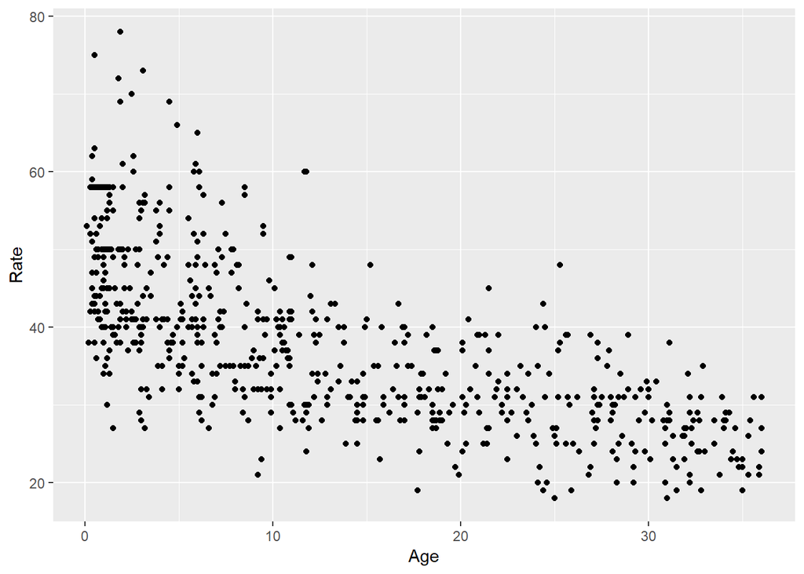

```r
ggplot(data = respiratory) + geom_point(mapping = aes(x = Age, y = Rate))
```

```r
cor(respiratory$Age, respiratory$Rate)
```

```
## [1] -0.6903627
```

The corelation between the Age and Rate is negative 0.69

```r
resp_model = lm(Rate ~ Age, data = respiratory)

summary(resp_model)
```

```
##
## Call:
## lm(formula = Rate ~ Age, data = respiratory)
##
## Residuals:
##     Min      1Q  Median      3Q     Max
## -19.652  -5.432  -0.608   4.589  32.270
##
## Coefficients:
##             Estimate Std. Error t value Pr(>|t|)
## (Intercept) 47.05216    0.50422   93.32   <2e-16 ***
## Age         -0.69571    0.02938  -23.68   <2e-16 ***
## ---
## Signif. codes:  0 '***' 0.001 '**' 0.01 '*' 0.05 '.' 0.1 ' ' 1
##
## Residual standard error: 7.842 on 616 degrees of freedom
## Multiple R-squared:  0.4766, Adjusted R-squared:  0.4758
## F-statistic: 560.9 on 1 and 616 DF,  p-value: < 2.2e-16
```

```r
confint(resp_model)
```

```
##                  2.5 %     97.5 %
## (Intercept) 46.0619711 48.0423556
## Age         -0.7534009 -0.6380259
```

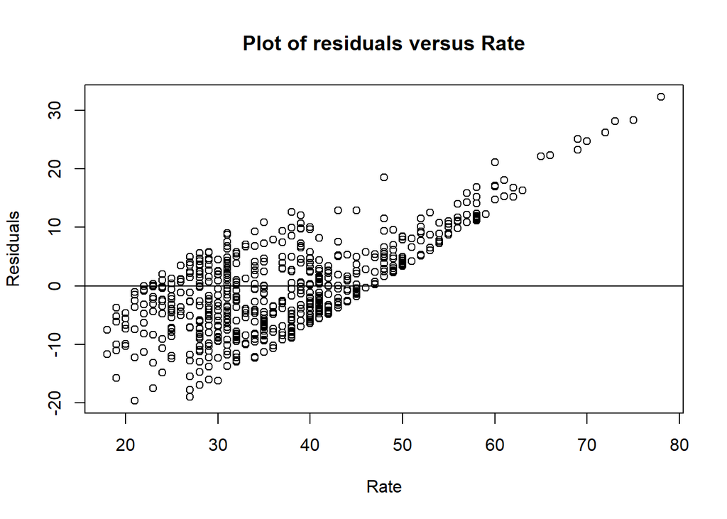

```r
plot(y = resp_model$residual, x=respiratory$Rate, ylab = "Residuals", xlab = "Rate", main = "Plot of residuals versus Rate")
abline(0,0)  #adds a horizontal line at zero to help with visualization
```

```r
respiratory$LogRate = log(respiratory$Rate)

summary(respiratory)
```

```
##        X              Age             Rate          LogRate
##  Min.   :  1.0   Min.   : 0.10   Min.   :18.00   Min.   :2.890
##  1st Qu.:155.2   1st Qu.: 3.80   1st Qu.:30.00   1st Qu.:3.401
##  Median :309.5   Median :10.55   Median :36.50   Median :3.597
##  Mean   :309.5   Mean   :13.39   Mean   :37.74   Mean   :3.591
##  3rd Qu.:463.8   3rd Qu.:22.00   3rd Qu.:44.00   3rd Qu.:3.784
##  Max.   :618.0   Max.   :36.00   Max.   :78.00   Max.   :4.357
```

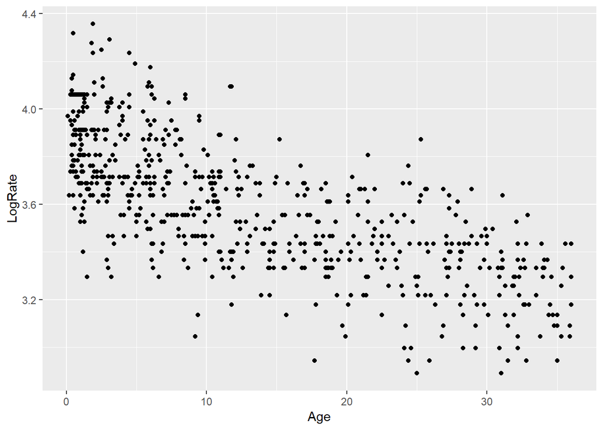

```r
ggplot(data = respiratory) + geom_point(mapping = aes(x = Age, y = LogRate))
```

```r
cor(respiratory$Age, respiratory$LogRate)
```

```
## [1] -0.7211918
```

We can see that the corelation between the Log of Rate and Age is negative 0.72 and also looking at the scatter plot of log rate and age, we can observe that there is a linear relationship and for futher assurance plotting the residual plot might be helpful.

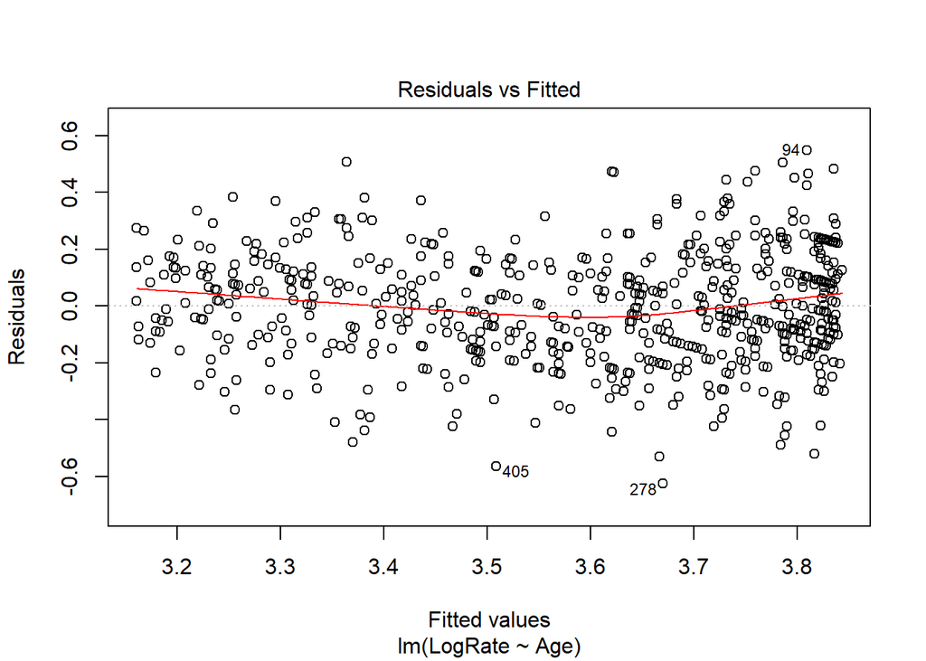

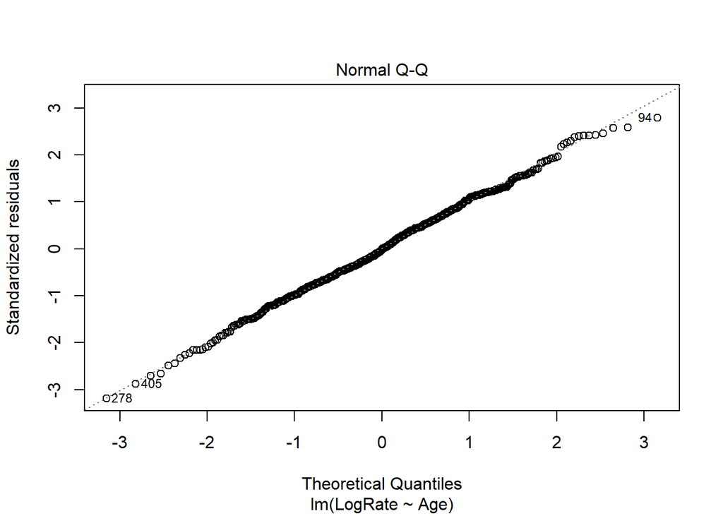

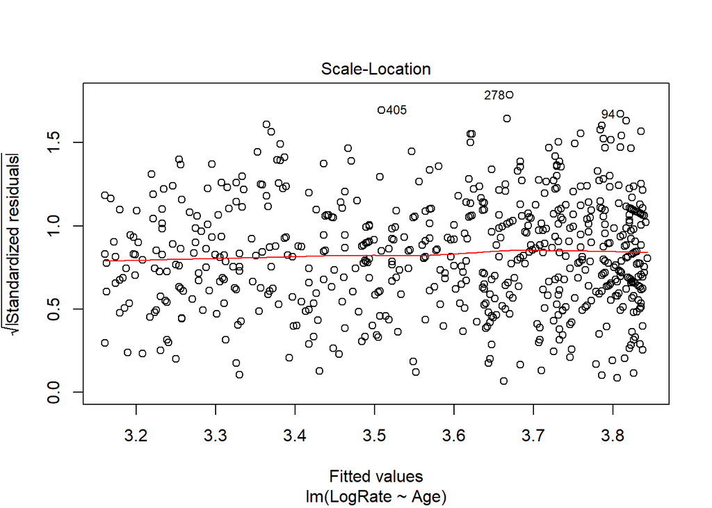

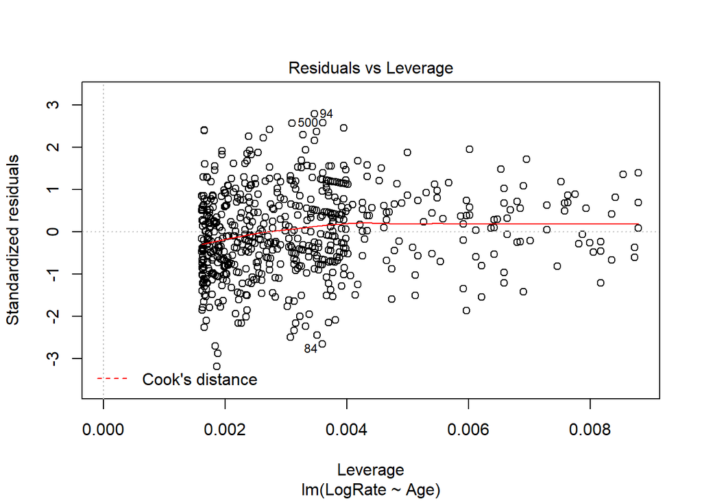

```r
resp_model2 = lm(LogRate ~ Age, data = respiratory)

plot(resp_model2)
```

Looking the Residual plot, we can see that the plot exhibits constant variance. Also, we can see from the qq plot that the residual exhibit a normal distribution.

```r
summary(resp_model2)
```

```
##
## Call:
## lm(formula = LogRate ~ Age, data = respiratory)
##
## Residuals:
##      Min       1Q   Median       3Q      Max
## -0.62571 -0.13201 -0.00402  0.13489  0.54771
##
## Coefficients:
##               Estimate Std. Error t value Pr(>|t|)
## (Intercept)  3.8451185  0.0126277  304.50   <2e-16 ***
## Age         -0.0190090  0.0007357  -25.84   <2e-16 ***
## ---
## Signif. codes:  0 '***' 0.001 '**' 0.01 '*' 0.05 '.' 0.1 ' ' 1
##
## Residual standard error: 0.1964 on 616 degrees of freedom
## Multiple R-squared:  0.5201, Adjusted R-squared:  0.5193
## F-statistic: 667.6 on 1 and 616 DF,  p-value: < 2.2e-16
```

```r
confint(resp_model2)
```

```
##                   2.5 %      97.5 %
## (Intercept)  3.82032007  3.86991701
## Age         -0.02045369 -0.01756423
```

The confidence interval of the model is -0.02 and -0.017. This means that 95% of the times the model captures the true value of the slope.

Using the model, we can find the prediction interval of the rate when the ages are 1, 18 and 29 months:

```r
new.age = c(1, 18, 29)
new.data = data.frame(Age = new.age)

exp(predict.lm(resp_model2, new.data, interval = "prediction"))
```

```
##        fit      lwr      upr
## 1 45.88368 31.17725 67.52721
## 2 33.21353 22.57614 48.86302
## 3 26.94664 18.30537 39.66714
```

```r
exp(-0.0190090)
```

```
## [1] 0.9811705
```

```r
#Exponential value of the slope
```